# 2051498-储岱泽-方差分析

首先导入数据

```r
# 指定数据文件路径
file_path <- "ANOVA_data_music.csv"

# 加载CSV文件
data <- read.csv(file_path)

# 查看数据框的结构
str(data)
```

```
'data.frame':   150 obs. of  3 variables:
 $ ID          : int  1 2 3 4 5 6 7 8 9 10 ...
 $ condition   : chr  "no_music" "no_music" "no_music" "no_music" ...
 $ productivity: num  188 196 194 190 157 ...
```

```r
# 查看数据的前几行
head(data)
```

|  | ID | condition | productivity |
| --- | --- | --- | --- |
| 1 | 1 | no_music | 187.6473 |
| 2 | 2 | no_music | 196.4893 |
| 3 | 3 | no_music | 194.3215 |
| 4 | 4 | no_music | 190.1110 |
| 5 | 5 | no_music | 156.7473 |
| 6 | 6 | no_music | 145.1821 |

```r
NA
NA
```

分别提取出control_group，treatment_group_1以及treatment_group_2这三个组。

```r
control_group<-subset(data,data$condition=='no_music')
treatment_group_1<-subset(data,data$condition=='music_no_choice')
treatment_group_2<-subset(data,data$condition=='music_choice')
```

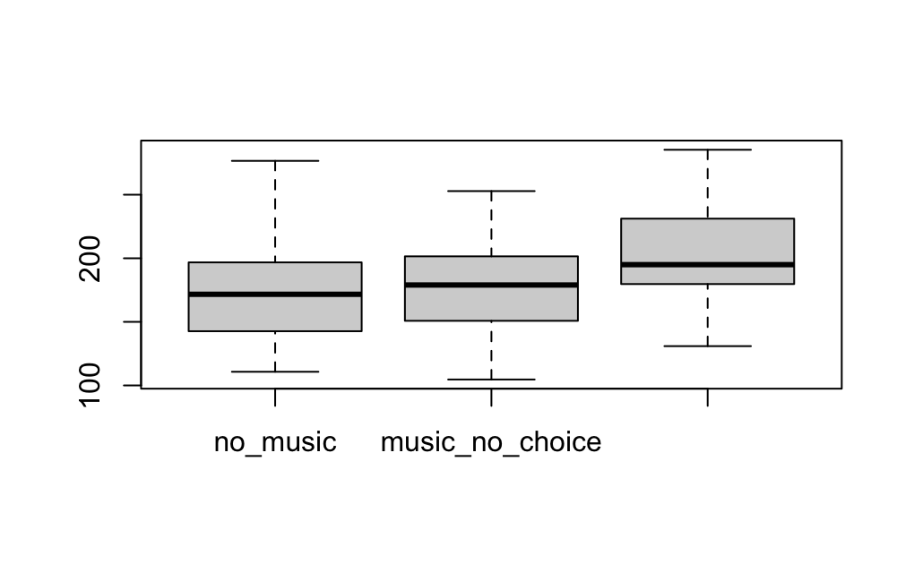

```r
# 假设已经定义了control_group, treatment_group_1, treatment_group_2

# 将数据整合成一个列表
data_list <- list(control_group$productivity, treatment_group_1$productivity, treatment_group_2$productivity)

# 画箱线图
boxplot(data_list, names=c('no_music', 'music_no_choice', 'music_choice'))
```

```r
# 使用stats输出最小值、下四分位数、中位数、上四分位数、最大值以及离群点
result <- boxplot(data_list, plot=FALSE)
result$stats  # 输出最小值、下四分位数、中位数、上四分位数、最大值
```

```
         [,1]     [,2]     [,3]
[1,] 110.7401 104.6698 130.9050
[2,] 142.6391 150.8186 179.7325
[3,] 171.6782 178.9807 194.9928
[4,] 196.7702 201.5226 231.1774
[5,] 276.6144 252.8472 285.3483
```

```r
result$out    # 输出离群点
```

```
numeric(0)
```

```r
# 进行方差分析
anova_result <- aov(productivity ~ condition, data = data)
summary(anova_result)
```

```
             Df Sum Sq Mean Sq F value   Pr(>F)
condition     2  24734   12367   9.291 0.000159 ***
Residuals   147 195661    1331
---
Signif. codes:  0 ‘***’ 0.001 ‘**’ 0.01 ‘*’ 0.05 ‘.’ 0.1 ‘ ’ 1
```

根据方差分析的结果，我们可以看到自变量“condition”对因变量的影响是显著的。具体来说，F值为9.291，对应的p值为0.000159，远小于一般的显著性水平（比如0.05）。这表示我们有足够的证据拒绝原假设，即不同条件下的平均值没有显著差异的假设。因此，我们可以得出结论，不同的条件对因变量有显著影响。

# 两两来看

使用t检验来看no_music和music_no_choice是否有明显差异。

```r
# 执行独立样本t检验
result <- t.test(control_group$productivity, treatment_group_1$productivity)
# 输出结果
print(result)
```

```
    Welch Two Sample t-test

data:  control_group$productivity and treatment_group_1$productivity
t = -0.36286, df = 94.389, p-value = 0.7175
alternative hypothesis: true difference in means is not equal to 0
95 percent confidence interval:
 -17.12278  11.83114
sample estimates:
mean of x mean of y
 174.4983  177.1442
```

- t值为-0.36286，表示两组之间的工作效率差异相对较小。
- df（自由度）为94.389，用于计算p值和置信区间。
- p值为0.7175，大于通常的显著性水平（例如0.05），这意味着在统计学上没有足够的证据拒绝原假设。原假设可以理解为两组之间的工作效率没有显著差异。
- 置信区间为(-17.12278, 11.83114)，表示我们对于两组均值之间的真实差异有95%的置信度落在这个区间内。
- 样本估计值显示控制组的平均工作效率为174.4983，处理组1的平均工作效率为177.1442。 总结来说，根据这次t检验的结果，在统计学上得出结论，即”no_music”组和”music_no_choice”组的工作效率之间没有显著差异。

使用t检验来看no_music和music_choice是否有明显差异。

```r
# 执行独立样本t检验
result <- t.test(control_group$productivity, treatment_group_2$productivity)
# 输出结果
print(result)
```

```
    Welch Two Sample t-test

data:  control_group$productivity and treatment_group_2$productivity
t = -3.7225, df = 97.263, p-value = 0.0003305
alternative hypothesis: true difference in means is not equal to 0
95 percent confidence interval:
 -43.64312 -13.28968
sample estimates:
mean of x mean of y
 174.4983  202.9647
```

```r
# 执行独立样本t检验
result <- t.test(treatment_group_1$productivity, treatment_group_2$productivity)
# 输出结果
print(result)
```

```
    Welch Two Sample t-test

data:  treatment_group_1$productivity and treatment_group_2$productivity
t = -3.7239, df = 96.819, p-value = 0.0003297
alternative hypothesis: true difference in means is not equal to 0
95 percent confidence interval:
 -39.58260 -12.05856
sample estimates:
mean of x mean of y
 177.1442  202.9647
```